# Galaxy Plots on Sims

Katie Lotterhos

1/16/2017

## Evaluating Galaxy plots with known simulation data

Recently I have been exploring the idea of visualizing SNP effect sizes to multiple environmental variables. Here, I am extending the results from the I am using the Lotterhos and Whitlock (2015) simulations to explore this concept in a known scenario. Basically, we want to know if the two distinct groups of behavior we observed in the dataset could be generated by chance if there is only one environmental variable driving the adapatation.

I have chosen three replicate datasets from the LW2015 simulations, that were simulated range expansions in a 1 refugia model, with 90 populations sampled and 20 individuals per population. This demography is similar to the range expansion we expect in lodgepole pine, which is the species and dataset I am applying the concept to (Adaptree data). The total sample size is also similar - in the paper I think we have ~600 diploids (1200 chromosomes), whereas here we have 1800 haploid chromosomes.

In LW2015, we simulated adaptation of loci to a single environmental variable (E_main).

Here, I am going to create two more environmental variables: one that is positively correlated with the selective environment (E_falsePlus), and one that is negatively correlated with the selective environment (E_falseMinus).

With this data, I am going to essentially repeat the steps that I took for the Adaptree data:

1. calculate uncorrected Spearman’s rho association between allele frequency ($f$) and environment ($E_i$) for E_main, E_falsePlus, and E_falseMinus.
2. choose outliers based on uncorrected Spearman’s rho as those that have P-values less than the Bonferroni correction. Hereafter these will be called the “candidate set”.
3. use Galaxy plots to visualize the candidate set in 2 dimensional space with 3 plots:
- E_main vs. E_falsePlus
- E_main vs. E_falseMinus
- E_falsePlus vs. E_falseMinus

I will conduct this exercise for datasets with just neutral loci (9900) and for datasets with neutral loci and loci simulated under varying strengths of selection (9900 and 100).

```r
setwd("Users/katie/Desktop/CurrResearch/1-AdaptreeData/201509_PEGA/simulations/")
```

### Load data

```r
snps <- read.table("data/LW2015data/1R_R90_1351142954_453_1_NumPops=90_NumInd=20.lfmm")
env <- read.table("data/LW2015data/1R_R90_1351142954_453_1_NumPops=90_NumInd=20.env")
df <- read.table("data/LW2015data/1R_R90_1351142954_453_1_NumPops=90_NumInd=20Bayenv2LFMMpca.Cpval", header=TRUE)

dim(snps)
```

```
## [1] 1800 9996
```

```r
dim(env)
```

```
## [1] 1800    1
```

### Create correlated environments

```r
  head(env[,1], 40)
```

```
##  [1] -3.730462 -3.730462 -3.730462 -3.730462 -3.730462 -3.730462 -3.730462
##  [8] -3.730462 -3.730462 -3.730462 -3.730462 -3.730462 -3.730462 -3.730462
## [15] -3.730462 -3.730462 -3.730462 -3.730462 -3.730462 -3.730462 -1.043307
## [22] -1.043307 -1.043307 -1.043307 -1.043307 -1.043307 -1.043307 -1.043307
## [29] -1.043307 -1.043307 -1.043307 -1.043307 -1.043307 -1.043307 -1.043307
## [36] -1.043307 -1.043307 -1.043307 -1.043307 -1.043307
```

```r
  # note that this is individual level data, but each population only has one environment measure

  pops <- seq(1, 1800-19, by=20)
  length(pops)
```

```
## [1] 90
```

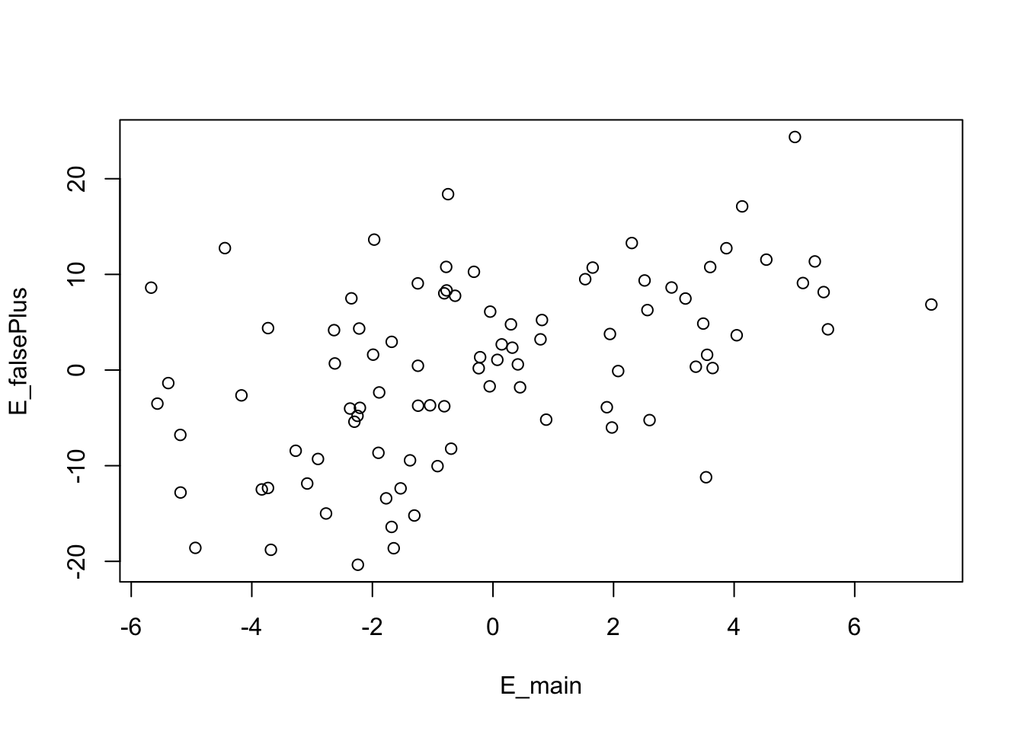

```r
  E_main <- env[pops,1]

  ### Falsely positively correlated variable
  E_falsePlus <- E_main * 2 + rnorm(length(E_main), sd=8)
  plot(E_main, E_falsePlus)
```

```r
  cor.test(E_main, E_falsePlus, method="spearman", exact=FALSE)
```

```
##
##  Spearman's rank correlation rho
##
## data:  E_main and E_falsePlus
## S = 61338, p-value = 7.024e-07
## alternative hypothesis: true rho is not equal to 0
## sample estimates:
##       rho
## 0.4950982
```

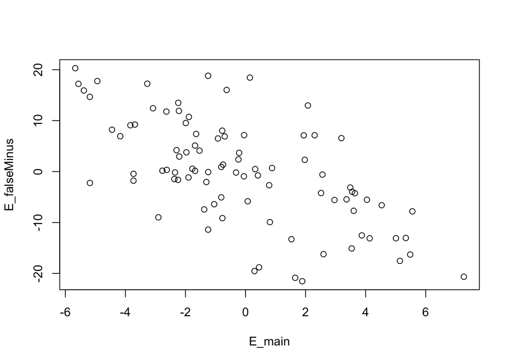

```r
  ### Falsely negatively correlated variable
  E_falseMinus <- E_main * -2 + rnorm(length(E_main), sd=8)
  plot(E_main, E_falseMinus)
```

```r
  cor.test(E_main, E_falseMinus, method="spearman", exact=FALSE)
```

```
##
##  Spearman's rank correlation rho
##
## data:  E_main and E_falseMinus
## S = 195690, p-value = 1.623e-10
## alternative hypothesis: true rho is not equal to 0
## sample estimates:
##        rho
## -0.6108491
```

```r
  env[,2] <- rep(E_falsePlus, each=20)
  env[,3] <- rep(E_falseMinus, each=20)


  # The two false variables are also correlated:
  cor.test(E_falsePlus, E_falseMinus, method="spearman", exact=FALSE)
```

```
##
##  Spearman's rank correlation rho
##
## data:  E_falsePlus and E_falseMinus
## S = 152780, p-value = 0.01424
## alternative hypothesis: true rho is not equal to 0
## sample estimates:
##        rho
## -0.2576038
```

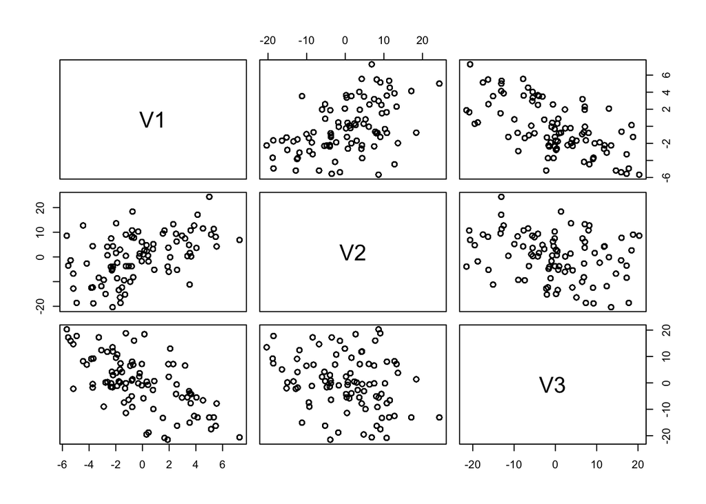

```r
  # Plot of the correlation structure among environments:
   plot(env)
```

### Calculate rho for all 3 environments

Create a matrix to hold Spearman’s rho and another matrix to hold P-values, where each row is a SNP and each column is an environmental variable

```r
TrueEnv.rho <- matrix(NA, ncol(snps), ncol(env))
TrueEnv.P <- matrix(NA, ncol(snps), ncol(env))

for (i in 1:ncol(snps)){
  for (j in 1:ncol(env)){
    test <- cor.test(snps[,i], env[,j], method="spearman", exact=FALSE)
    TrueEnv.rho[i,j] <- test$estimate
    TrueEnv.P[i,j] <- test$p.value
  }
}
```

### Get indices of neutral and selected SNPs

(not shown)

```
## [1] 9900
```

```
## [1] 96
```

```
##  [1]  9901  9902  9903  9904  9905  9906  9907  9908  9909  9910  9911
## [12]  9912  9913  9914  9915  9916  9917  9918  9919  9920  9921  9922
## [23]  9923  9924  9925  9926  9927  9928  9929  9930  9931  9932  9933
## [34]  9934  9935  9936  9937  9938  9939  9940  9941  9942  9943  9944
## [45]  9945  9946  9947  9948  9949  9951  9952  9953  9954  9955  9956
## [56]  9957  9958  9959  9960  9961  9962  9963  9964  9965  9966  9967
## [67]  9968  9969  9970  9971  9972  9973  9974  9975  9977  9978  9980
## [78]  9981  9982  9983  9984  9985  9986  9987  9988  9989  9990  9991
## [89]  9992  9993  9995  9996  9997  9998  9999 10000
```

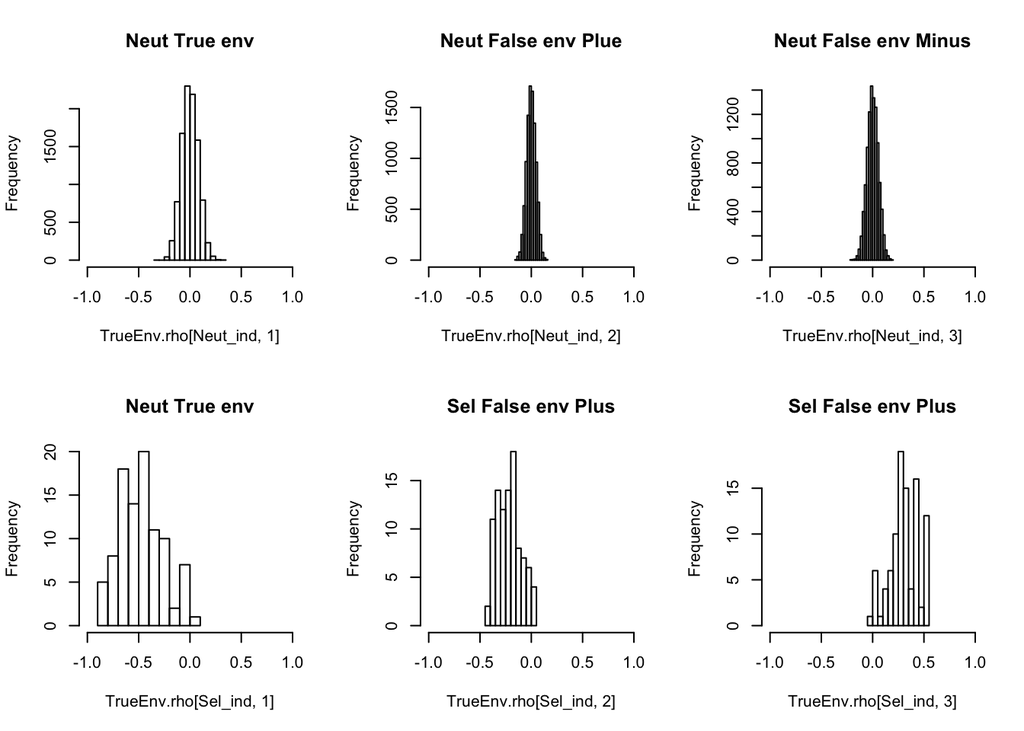

The above plot shows the distribution of Spearman’s rho for the three environments, with neutral loci in the top row and selected loci in the bottom row.

### How many are significant

I determined which loci were “outliers” by the criteria that they had to have p-values from Spearman’s rho less than expected by Bonferroni correction.

The false positive rate is really high in the “main” environment (See: “Number false positives in landscape sims” in R code). This might be because the main environment correlates with the population structure; e.g. the range expansion was south the north, and so is the environmental cline. (This makes me think we should use more stringent criteria for the pine paper, since the Temperature-related variables are the ones that correlate the strongest with population structure and those are the ones we see the most outliers in.)

```r
(Bonferroni_P_N <- -log10(0.05/(10000*3)))
```

```
## [1] 5.778151
```

```r
### Number false positives in landscape sims
colSums(-log10(TrueEnv.P[Neut_ind,])>Bonferroni_P_N)
```

```
## [1] 1616  110  387
```

```r
  # The false positive rate is really high in the "main" environment (first column). This might be because the causal environment correlates with the population structure; e.g. the range expansion was south the north, and so is the environmental cline.


### Number true positives in landscape sims
colSums(-log10(TrueEnv.P[Sel_ind,])>Bonferroni_P_N)
```

```
## [1] 88 77 88
```

```r
  #(total selected loci in this dataset is 96)

Is.Sig <- -log10(TrueEnv.P)>Bonferroni_P_N
dim(Is.Sig)
```

```
## [1] 9996    3
```

```r
# As a first pass, we call a snp an outlier if it is an outlier in any one environmental variable
Is.Out <- (rowSums(Is.Sig)>0)

# The number of "outliers" that are neutral is slightly larger than the number of outliers in the "main" environment:
sum(Is.Out[Neut_ind])
```

```
## [1] 1656
```

```r
# Number of "outliers" that are under selection is the same as the number in the "main" environment
sum(Is.Out[Sel_ind])
```

```
## [1] 88
```

### Galaxy plots

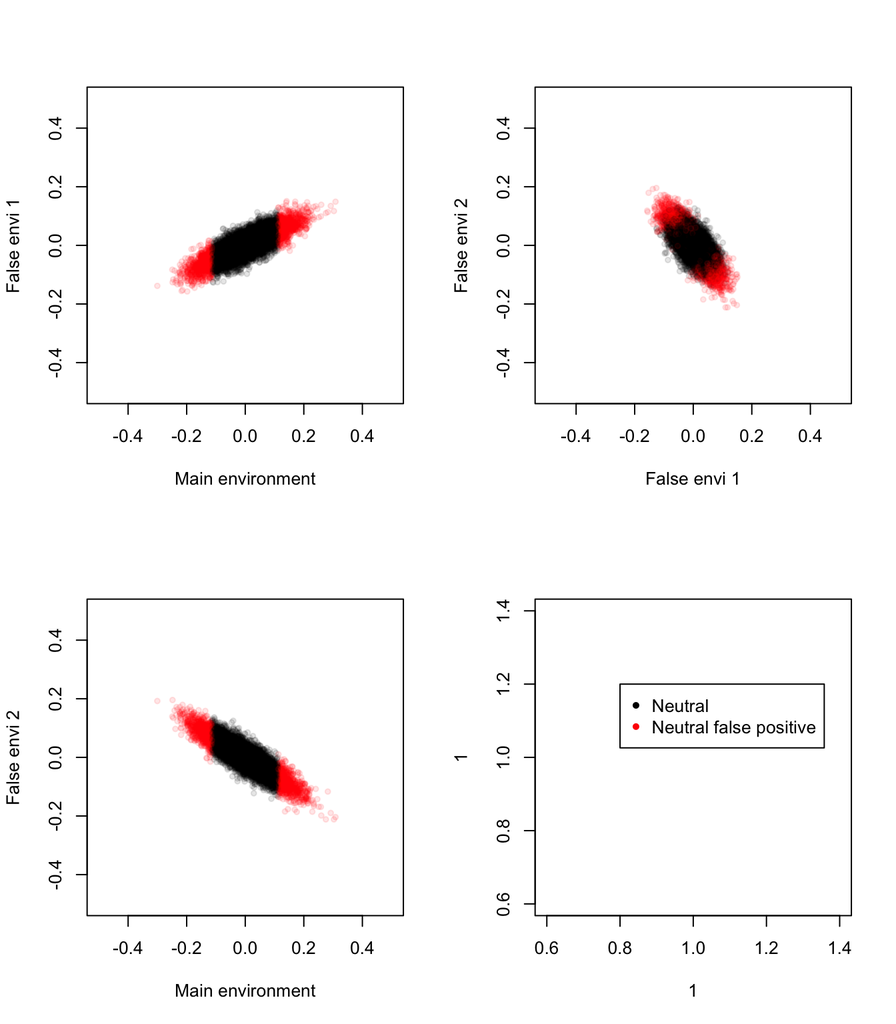

The main result is the false positives are expected to follow the orientation of the genome-wide null distribution, no matter what combinations of environmental variables we look at.

This makes me think maybe an eigenvector would be a better test of behavior rather than a covariance, with the null hypothesis that the eigenvector of a focal group of SNPs is significantly different from the genome-wide expected direction. This null hypothesis should hold true in any combination of environmental variables.

**In the Adaptree dataset, we see two distinct groups of behavior at non-overlapping groups of SNPs, which was not observed here**

In these simulations, true positives also follow the orientation of the genome-wide null distribution, but are even moreso “outliers”. This illustrates a potential problem with the eigenvector approach, which would overlook “true” positives that are only adapting to a single environmental variable.

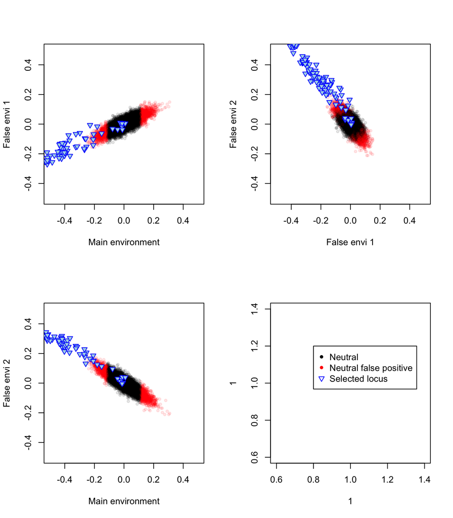